# Simple graphs/tables

Mathilde Le Vu

2022-07-10

## State and world region of birth

```r
# State of birth in : Switzerland or Outside of Switzerland
  table(bevn_eco$country_of_birth_cat1, useNA = "always")
```

```
##
##         Switzerland Outside Switzerland                <NA>
##             1202203              124074                   1
```

```r
  round(prop.table(table(bevn_eco$country_of_birth_cat1, useNA="always"))*100,2)
```

```
##
##         Switzerland Outside Switzerland                <NA>
##               90.64                9.36                0.00
```

```r
#State of birth in : Switzerland, Europe, Africa, Americas, Asia, Oceania, other
table(bevn_eco$country_of_birth_cat2, useNA = "always")
```

```
##
##         Switzerland Europe - excl Switz              Africa            Americas                Asia
##             1202203               75785                4066               24656               18587
##             Oceania               Other                <NA>
##                 980                   0                   1
```

```r
round(prop.table(table(bevn_eco$country_of_birth_cat2, useNA="always"))*100,2)
```

```
##
##         Switzerland Europe - excl Switz              Africa            Americas                Asia
##               90.64                5.71                0.31                1.86                1.40
##             Oceania               Other                <NA>
##                0.07                0.00                0.00
```

```r
#State of birth in : Switzerland, different parts of Europe, other
round(prop.table(table(bevn_eco$country_of_birth_cat3, useNA="always"))*100,2)
```

```
##
##  Central Europe  Eastern Europe Northern Europe           other       SE Europe Southern Europe
##            1.60            0.04            0.17            3.65            0.11            0.65
##       SW Europe           Switz  Western Europe            <NA>
##            0.27           90.64            2.87            0.00
```

There are **124,074** births that occurred outside of Switzerland.

## Nationality Mother

```r
summary(bevn_eco$mother_nationality)
```

```
##    Min. 1st Qu.  Median    Mean 3rd Qu.    Max.
##    8100    8100    8100    8178    8231    8999
```

```r
table(bevn_eco$mother_nationality, useNA="always")
```

```
##
##   8100   8201   8202   8204   8205   8206   8207   8211   8212   8214   8215   8216   8217   8218   8222
## 787347   1068      7   3137   1840   1187  74240   1350  40084   2184   9053    959    109  36949   1843
##   8223   8224   8226   8227   8228   8229   8230   8231   8232   8233   8234   8236   8239   8240   8242
##    255     55      4   3531    673   7664   7875  45681   4902      6   2501  13200  16299   4345     90
##   8243   8244   8248   8250   8251   8252   8254   8255   8256   8260   8261   8262   8263   8264   8265
##   4506   2714  25327   6157    995   7515    646  21298  32024    350    812    690    591   6903   3499
##   8266   8301   8302   8303   8304   8305   8307   8308   8309   8310   8311   8312   8313   8314   8315
##    688     17   1671     26   2090    996     11    115    112    880     58    136    533     74    416
##   8317   8319   8320   8321   8322   8323   8324   8325   8326   8327   8329   8330   8331   8332   8333
##   2006    351    749      7     95   2089     13     32    292    451     17     83   4727     21    362
##   8334   8335   8336   8337   8340   8341   8343   8344   8345   8346   8347   8348   8349   8350   8351
##     52     51    947    204     84    197     57      9    653     16     60   2801   1182    330     51
##   8352   8353   8354   8356   8357   8358   8359   8360   8362   8363   8401   8402   8403   8405   8406
##      2    123    526     52   3453    184    803     10  10197     12   1957     14      4   1183  11339
##   8407   8408   8409   8410   8411   8415   8417   8418   8419   8420   8421   8423   8424   8425   8427
##   1391    249   2550   1344    186    213      5    180      1    231     89   4081   2254    669   2045
##   8429   8430   8431   8432   8435   8436   8437   8438   8439   8440   8441   8442   8443   8445   8501
##    249    120    454   1915     10     38    176    800   9065     11      1      2      3      9   2180
##   8502   8503   8504   8505   8506   8507   8508   8510   8511   8512   8513   8514   8515   8516   8517
##     12     11      5     57   6705    396   5526   3425    916   2644   1042   2966   2998    195    248
##   8518   8519   8521   8522   8523   8525   8526   8527   8528   8529   8530   8532   8533   8534   8535
##    410     10     26    105   1525    460     10     25    584    156      2     12   1534   2727    148
##   8537   8539   8541   8542   8543   8545   8546   8550   8560   8561   8562   8563   8564   8565   8566
##    504    880   3825   4165     43   1704    947    166    270    195    284    397    146     37     26
##   8567   8601   8602   8605   8607   8608   8610   8612   8614   8616   8998   8999   <NA>
##    263   2189     16      3    551     12      3      5      7      1     49   6053      0
```

```r
# Nationality of the mother in : Switzerland or Outside of Switzerland
  round(prop.table(table(bevn_eco$mother_nationality_cat1, useNA="always"))*100,2)
```

```
##
##         Switzerland Outside Switzerland                <NA>
##               59.37               40.63                0.00
```

```r
    round(prop.table(table(bevn_eco_in7$mother_nationality_cat1, useNA="always"))*100,2)
```

```
##
##         Switzerland Outside Switzerland                <NA>
##               61.47               38.53                0.00
```

```r
# Nationality of the mother in : Switzerland, Europe, Africa, Americas, Asia, Oceania, other
  round(prop.table(table(bevn_eco$mother_nationality_cat2, useNA="always"))*100,2)
```

```
##
##         Switzerland Europe - excl Switz              Africa            Americas                Asia
##               59.37               29.84                3.05                3.23                4.00
##             Oceania               Other                <NA>
##                0.05                0.46                0.00
```

```r
  round(prop.table(table(bevn_eco_in7$mother_nationality_cat2, useNA="always"))*100,2)
```

```
##
##         Switzerland Europe - excl Switz              Africa            Americas                Asia
##               61.47               29.25                2.88                2.43                3.58
##             Oceania               Other                <NA>
##                0.02                0.36                0.00
```

```r
#Nationality of the mother in : Switzerland, different parts of Europe, other
  round(prop.table(table(bevn_eco$mother_nationality_cat3, useNA="always"))*100,2)
```

```
##
##  Central Europe  Eastern Europe Northern Europe           other       SE Europe Southern Europe
##            7.45            1.02            0.44           11.12            7.67            4.19
##       SW Europe           Switz  Western Europe            <NA>
##            4.44           59.37            4.30            0.00
```

```r
    round(prop.table(table(bevn_eco_in7$mother_nationality_cat3, useNA="always"))*100,2)
```

```
##
##  Central Europe  Eastern Europe Northern Europe           other       SE Europe Southern Europe
##            6.89            0.99            0.39            9.62            8.46            4.29
##       SW Europe           Switz  Western Europe            <NA>
##            4.74           61.47            3.14            0.00
```

## Place of residence Mother

1-6910 for commune if resident inside Switz  
8201-8703 if resident outside of Switz

```r
#to check minimum and maximum
summary(bevn_eco$com)
```

```
##    Min. 1st Qu.  Median    Mean 3rd Qu.    Max.    NA's
##       1     768    3218    3504    5725    8619    1921
```

```r
head(bevn_eco$com,50)
```

```
##  [1] 1061 6743 1061 6640 6633 6613 6421 4006  246 6158  768 6628 1707 6458 4303  199  415 4208 2422 2767
## [21]  351 5586 8212 2791 2301 4140 4229 2546  700  383 6007 2701 1065  243 6643 3340  100  177  194  198
## [41]  172  261 1008  158   90 1707  261 1061 4165 6771
```

```r
# Place of residence of the mother in : inside or outside Switzerland
  round(prop.table(table(bevn_eco$mother_residence_cat1, useNA="always"))*100,2)
```

```
##
##         Switzerland Outside Switzerland                <NA>
##               88.75               11.10                0.14
```

```r
  table(bevn_eco$mother_residence_cat1, useNA="always")
```

```
##
##         Switzerland Outside Switzerland                <NA>
##             1177097              147260                1921
```

## Status of Residence of the mother

1=permanent resident, 2=non-permanent resident, 4=short stay, 9=domiciled abroad

```r
summary(bevn_eco$resident_status)
```

```
##    Min. 1st Qu.  Median    Mean 3rd Qu.    Max.
##   1.000   1.000   1.000   1.908   1.000   9.000
```

```r
table(bevn_eco$resident_status, useNA = "always")
```

```
##
##       1       2       4       9    <NA>
## 1167672    8411    1014  149181       0
```

```r
round(prop.table(table(bevn_eco$resident_status, useNA="always"))*100,2)
```

```
##
##     1     2     4     9  <NA>
## 88.04  0.63  0.08 11.25  0.00
```

```r
table(bevn_eco$mother_nationality_cat1, bevn_eco$resident_status)
```

```
##
##                            1      2      4      9
##   Switzerland         716339      6      0  71002
##   Outside Switzerland 451333   8405   1014  78179
```

## Nationality father

See separate codebook. Expected: 8100-8703

```r
# categorizing nationality of the father in : inside or outside Switzerland
  round(prop.table(table(bevn_eco$father_nationality_cat1, useNA="always"))*100,2)
```

```
##
##         Switzerland Outside Switzerland                <NA>
##               58.20               39.56                2.24
```

```r
  table(bevn_eco$father_nationality_cat1, useNA="always")
```

```
##
##         Switzerland Outside Switzerland                <NA>
##              771897              524637               29744
```

```r
  round(prop.table(table(bevn_eco_in7$father_nationality_cat1, useNA="always"))*100,2)
```

```
##
##         Switzerland Outside Switzerland                <NA>
##               60.47               37.81                1.72
```

```r
  table(bevn_eco_in7$father_nationality_cat1, useNA="always")
```

```
##
##         Switzerland Outside Switzerland                <NA>
##              667422              417378               19013
```

## lebend geboren oder nicht = born alive or not

1=lifeborn, 2=stillborn

```r
table(bevn_eco$stillbirth, useNA = "always")
```

```
##
##       0       1    <NA>
## 1321060    5218       0
```

```r
round(prop.table(table(bevn_eco$stillbirth, useNA="always"))*100,3)
```

```
##
##      0      1   <NA>
## 99.607  0.393  0.000
```

```r
round(prop.table(table(bevn_eco_in3$stillbirth, useNA="always"))*100,3)
```

```
##
##      0      1   <NA>
## 99.613  0.387  0.000
```

## Gestational age

```r
## GA in weeks
summary(bevn_eco$GA_weeks)
```

```
##    Min. 1st Qu.  Median    Mean 3rd Qu.    Max.    NA's
##   16.00   38.57   39.57   39.22   40.43   45.86  138581
```

```r
summary(bevn_eco_in7$GA_weeks)
```

```
##    Min. 1st Qu.  Median    Mean 3rd Qu.    Max.
##   20.43   38.71   39.57   39.40   40.43   45.86
```

## Length at birth (cm)

```r
summary(bevn_eco$BL)
```

```
##    Min. 1st Qu.  Median    Mean 3rd Qu.    Max.    NA's
##    1.00   48.00   50.00   49.31   51.00   64.00  124295
```

```r
table(bevn_eco$BL, useNA = "always")
```

```
##
##      1      5      8      9     10     11     12     13     14     15     16     17     18     19     20
##      2      1      1      1      6      4      2      2      2     21     15     26     50     44    102
##     21     22     23     24     25     26     27     28     29     30     31     32     33     34     35
##     84    126    136    181    239    333    439    564    556    785    710    793    825    884    959
##     36     37     38     39     40     41     42     43     44     45     46     47     48     49     50
##   1052   1175   1460   1720   2624   3449   5450   8545  14849  27706  52684  96281 152658 193518 236018
##     51     52     53     54     55     56     57     58     59     60     61     62     63     64   <NA>
## 175481 116488  59628  27437  10078   3976   1215    391    147     45      7      3      4      1 124295
```

```r
summary(bevn_eco_in7$BL)
```

```
##    Min. 1st Qu.  Median    Mean 3rd Qu.    Max.
##   20.00   48.00   50.00   49.53   51.00   64.00
```

## Weight at birth (g)

```r
summary(bevn_eco$BW)
```

```
##    Min. 1st Qu.  Median    Mean 3rd Qu.    Max.    NA's
##       3    3000    3320    3285    3640    9351  124331
```

```r
summary(bevn_eco_in7$BW)
```

```
##    Min. 1st Qu.  Median    Mean 3rd Qu.    Max.
##       3    3040    3350    3331    3650    9351
```

```r
#BW categ. in LBW (<2500g) "normal" (arbitrary decision=2500-5000g) and high BW (>5000)
table(bevn_eco$BW_cat, useNA="always")
```

```
##
##     LBW     NBW     HBW    <NA>
##   83665 1117761     521  124331
```

```r
round(prop.table(table(bevn_eco$BW_cat, useNA="always"))*100, 3)
```

```
##
##    LBW    NBW    HBW   <NA>
##  6.308 84.278  0.039  9.374
```

```r
table(bevn_eco_in7$BW_cat, useNA="always")
```

```
##
##     LBW     NBW     HBW    <NA>
##   51480 1051838     495       0
```

```r
round(prop.table(table(bevn_eco_in7$BW_cat, useNA="always"))*100, 3)
```

```
##
##    LBW    NBW    HBW   <NA>
##  4.664 95.291  0.045  0.000
```

## Number of babies

1=singleton, 2=twins, 3=triplets, …, 6=sextuplets and more

```r
table(bevn_eco$nb_of_babies, useNA="always")
```

```
##
##       1       2       3       4       5    <NA>
## 1278139   46836    1266      32       5       0
```

```r
round(prop.table(table(bevn_eco$nb_of_babies, useNA="always"))*100,2)
```

```
##
##     1     2     3     4     5  <NA>
## 96.37  3.53  0.10  0.00  0.00  0.00
```

```r
##Single VS multiple pregnancies
table(bevn_eco$singleton_or_multiple)
```

```
##
## singleton  multiple
##   1278139     48139
```

```r
round(prop.table(table(bevn_eco$singleton_or_multiple, useNA="always"))*100,2)
```

```
##
## singleton  multiple      <NA>
##     96.37      3.63      0.00
```

## Parity

```r
table(bevn_eco$parity_cat, useNA = "always")
```

```
##
##  (0,1]  (1,2]  (2,3] (3,20]   <NA>
## 647597 478533 147555  47350   5243
```

```r
round(prop.table(table(bevn_eco$parity_cat, useNA="always"))*100,2)
```

```
##
##  (0,1]  (1,2]  (2,3] (3,20]   <NA>
##  48.83  36.08  11.13   3.57   0.40
```

```r
table(bevn_eco_in7$parity_cat, useNA = "always")
```

```
##
##  (0,1]  (1,2]  (2,3] (3,20]   <NA>
## 545684 402511 121076  34542      0
```

```r
round(prop.table(table(bevn_eco_in7$parity_cat, useNA="always"))*100,2)
```

```
##
##  (0,1]  (1,2]  (2,3] (3,20]   <NA>
##  49.44  36.47  10.97   3.13   0.00
```

## Maternal and paternal age

```r
summary(bevn_eco$mat_age)
```

```
##    Min. 1st Qu.  Median    Mean 3rd Qu.    Max.
##   11.00   28.00   32.00   31.47   35.00   67.00
```

```r
summary(bevn_eco_in7$mat_age)
```

```
##    Min. 1st Qu.  Median    Mean 3rd Qu.    Max.
##   12.00   28.00   31.00   31.35   35.00   50.00
```

```r
round(prop.table(table(bevn_eco_in7$mat_age_cat))*100,2)
```

```
##
## (25,30] (10,20] (20,25] (30,35] (35,40] (40,70]
##   27.89    1.18    9.79   37.41   19.94    3.80
```

```r
summary(bevn_eco$pat_age)
```

```
##    Min. 1st Qu.  Median    Mean 3rd Qu.    Max.    NA's
##   13.00   30.00   34.00   34.58   38.00   93.00   25964
```

```r
summary(bevn_eco_in7$pat_age)
```

```
##    Min. 1st Qu.  Median    Mean 3rd Qu.    Max.    NA's
##   13.00   30.00   34.00   34.41   38.00   93.00   16010
```

```r
 table(bevn_eco_in7$pat_age_cat, useNA = "always")
```

```
##
##  (10,20]  (20,30]  (30,40]  (40,50]  (50,70] (70,100]     <NA>
##     3298   251893   655817   160036    16578      181    16010
```

```r
 round(prop.table(table(bevn_eco_in7$pat_age_cat))*100,2)
```

```
##
##  (10,20]  (20,30]  (30,40]  (40,50]  (50,70] (70,100]
##     0.30    23.16    60.29    14.71     1.52     0.02
```

## Age difference between parents

```r
summary(bevn_eco_in7$parent_age_diff)
```

```
##    Min. 1st Qu.  Median    Mean 3rd Qu.    Max.    NA's
## -31.000   0.000   2.000   3.028   5.000  54.000   16010
```

## Mothers inside Switz without GMNDR: to check the number of missing

```r
table(bevn_eco_in7$com1, bevn_eco_in7$mother_residence_cat1, useNA = "always")
```

```
##
##                 Switzerland Outside Switzerland   <NA>
##   [1,1e+03]          343741                   0      0
##   (1e+03,2e+03]      112312                   0      0
##   (2e+03,3e+03]      144686                   0      0
##   (3e+03,4e+03]      100416                   0      0
##   (4e+03,5e+03]      121987                   0      0
##   (5e+03,6e+03]      147771                   0      0
##   <NA>               132900                   0      0
```

# Ecological variables

## Language

```r
  table(bevn_eco$Language,  useNA="always")
```

```
##
##      1      2      3      4   <NA>
## 830170 303001  41298   2628 149181
```

```r
  round(prop.table(table(bevn_eco$Language,  useNA="always"))*100,2)
```

```
##
##     1     2     3     4  <NA>
## 62.59 22.85  3.11  0.20 11.25
```

```r
  table(bevn_eco_in7$Language,  useNA="always")
```

```
##
##      1      2      3      4   <NA>
## 786931 274983  39407   2492      0
```

```r
  round(prop.table(table(bevn_eco_in7$Language,  useNA="always"))*100,2)
```

```
##
##     1     2     3     4  <NA>
## 71.29 24.91  3.57  0.23  0.00
```

```r
 # BW category and language region
  table(bevn_eco$BW_cat, bevn_eco$Language)
```

```
##
##            1      2      3      4
##   LBW  53744  24262   3050    179
##   NBW 773056 277431  38028   2440
##   HBW    426     82      3      1
```

```r
  round(prop.table(table(bevn_eco$BW_cat,bevn_eco$Language, useNA="always"), margin=2)*100,2)
```

```
##
##            1     2     3     4  <NA>
##   LBW   6.47  8.01  7.39  6.81  1.63
##   NBW  93.12 91.56 92.08 92.85 17.97
##   HBW   0.05  0.03  0.01  0.04  0.01
##   <NA>  0.35  0.40  0.53  0.30 80.40
```

```r
  table(bevn_eco_in7$BW_cat, bevn_eco_in7$Language)
```

```
##
##            1      2      3      4
##   LBW  34086  15136   2123    135
##   NBW 752426 259775  37281   2356
##   HBW    419     72      3      1
```

```r
  round(prop.table(table(bevn_eco_in7$BW_cat,bevn_eco_in7$Language, useNA="always"), margin=2)*100,2)
```

```
##
##            1     2     3     4 <NA>
##   LBW   4.33  5.50  5.39  5.42
##   NBW  95.62 94.47 94.61 94.54
##   HBW   0.05  0.03  0.01  0.04
##   <NA>  0.00  0.00  0.00  0.00
```

## Urban variables

1 is urban, 0 is rural

```r
 table(bevn_eco$Urban3)
```

```
##
##      0      1
## 591925 585172
```

```r
 round(prop.table(table(bevn_eco$Urban3,  useNA="always"))*100,2)
```

```
##
##     0     1  <NA>
## 44.63 44.12 11.25
```

```r
round(prop.table(table(bevn_eco_in7$Urban3,  useNA="always"))*100,2)
```

```
##
##     0     1  <NA>
## 50.61 49.39  0.00
```

## Grossregion

```r
table(bevn_eco$Grossregion)
```

```
##
##      1      2      3      4      5      6      7
## 234952 251387 154254 226278 157619 112909  39698
```

```r
round(prop.table(table(bevn_eco$Grossregion,  useNA="always"))*100,2)
```

```
##
##     1     2     3     4     5     6     7  <NA>
## 17.72 18.95 11.63 17.06 11.88  8.51  2.99 11.25
```

```r
round(prop.table(table(bevn_eco_in7$Grossregion,  useNA="always"))*100,2)
```

```
##
##     1     2     3     4     5     6     7  <NA>
## 19.32 21.36 13.22 19.37 13.57  9.72  3.43  0.00
```

## Altitude

```r
summary(bevn_eco$mean_Alt_mean2)
```

```
##    Min. 1st Qu.  Median    Mean 3rd Qu.    Max.    NA's
##   208.2   428.6   481.3   537.2   595.8  1941.2  149181
```

```r
summary(bevn_eco_in7$mean_Alt_mean2)
```

```
##    Min. 1st Qu.  Median    Mean 3rd Qu.    Max.
##   208.2   429.2   481.9   537.2   595.8  1941.2
```

## SSEP

```r
summary(bevn_eco$mean_ssep2)
```

```
##    Min. 1st Qu.  Median    Mean 3rd Qu.    Max.    NA's
##   23.63   52.02   58.64   58.16   64.28   86.68  149181
```

```r
summary(bevn_eco_in7$mean_ssep2)
```

```
##    Min. 1st Qu.  Median    Mean 3rd Qu.    Max.
##   23.63   52.02   58.57   58.16   64.32   86.68
```

# Simple tables

## Gestational age through the years

```r
#calculating median by year
 GA_median <- aggregate(GA_weeks ~ birthyear, data = bevn_eco_in7, median) # from 2006 it was systematically collected
 GA_median
```

```
##    birthyear GA_weeks
## 1       2007 39.57143
## 2       2008 39.57143
## 3       2009 39.57143
## 4       2010 39.57143
## 5       2011 39.57143
## 6       2012 39.57143
## 7       2013 39.57143
## 8       2014 39.57143
## 9       2015 39.57143
## 10      2016 39.57143
## 11      2017 39.71429
## 12      2018 39.71429
## 13      2019 39.71429
## 14      2020 39.71429
```

```r
#same but using tidyverse
 gamedian <- bevn_eco_in7 %>%
   group_by(birthyear) %>%
     filter( !is.na(GA_weeks)) %>%
   summarise(medGA=format(median(GA_weeks),digits=5))
ungroup(gamedian)
```

```
## # A tibble: 14 x 2
##    birthyear medGA
##        <int> <chr>
##  1      2007 39.571
##  2      2008 39.571
##  3      2009 39.571
##  4      2010 39.571
##  5      2011 39.571
##  6      2012 39.571
##  7      2013 39.571
##  8      2014 39.571
##  9      2015 39.571
## 10      2016 39.571
## 11      2017 39.714
## 12      2018 39.714
## 13      2019 39.714
## 14      2020 39.714
```

```r
gamedian
```

```
## # A tibble: 14 x 2
##    birthyear medGA
##        <int> <chr>
##  1      2007 39.571
##  2      2008 39.571
##  3      2009 39.571
##  4      2010 39.571
##  5      2011 39.571
##  6      2012 39.571
##  7      2013 39.571
##  8      2014 39.571
##  9      2015 39.571
## 10      2016 39.571
## 11      2017 39.714
## 12      2018 39.714
## 13      2019 39.714
## 14      2020 39.714
```

```r
 #creating a function to calculate the mode of a variable
getmode <- function(v) {
   uniqv <- na.omit(unique(v))
   uniqv[which.max(tabulate(match(v, uniqv)))]
}
# Calculate the GA mode through the years
ga_mode <- bevn_eco_in7 %>%
   group_by(birthyear) %>%
     filter( !is.na(GA_weeks)) %>%
   summarise(mode=format(getmode(GA_weeks), digits=7))
ungroup(ga_mode)
```

```
## # A tibble: 14 x 2
##    birthyear mode
##        <int> <chr>
##  1      2007 40
##  2      2008 40
##  3      2009 40.14286
##  4      2010 40
##  5      2011 40.14286
##  6      2012 40
##  7      2013 40.14286
##  8      2014 40.14286
##  9      2015 40.14286
## 10      2016 40.14286
## 11      2017 40.14286
## 12      2018 40.14286
## 13      2019 40.14286
## 14      2020 40.14286
```

```r
ga_mode
```

```
## # A tibble: 14 x 2
##    birthyear mode
##        <int> <chr>
##  1      2007 40
##  2      2008 40
##  3      2009 40.14286
##  4      2010 40
##  5      2011 40.14286
##  6      2012 40
##  7      2013 40.14286
##  8      2014 40.14286
##  9      2015 40.14286
## 10      2016 40.14286
## 11      2017 40.14286
## 12      2018 40.14286
## 13      2019 40.14286
## 14      2020 40.14286
```

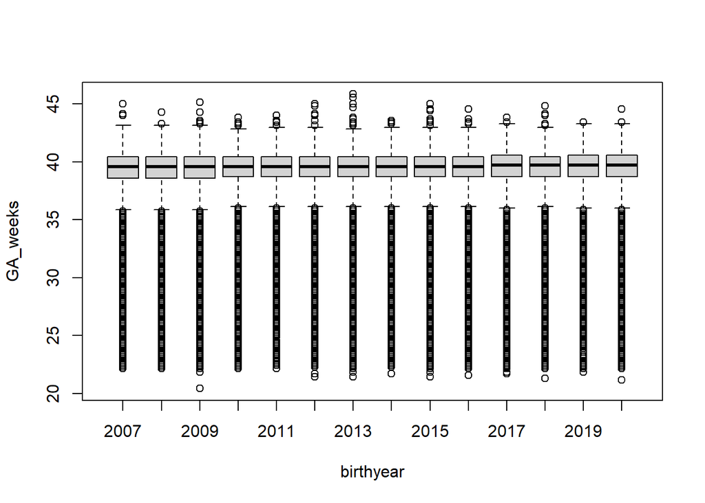

```r
## GA frequency tables through the years
boxplot(GA_weeks ~birthyear, data=bevn_eco_in7)
```

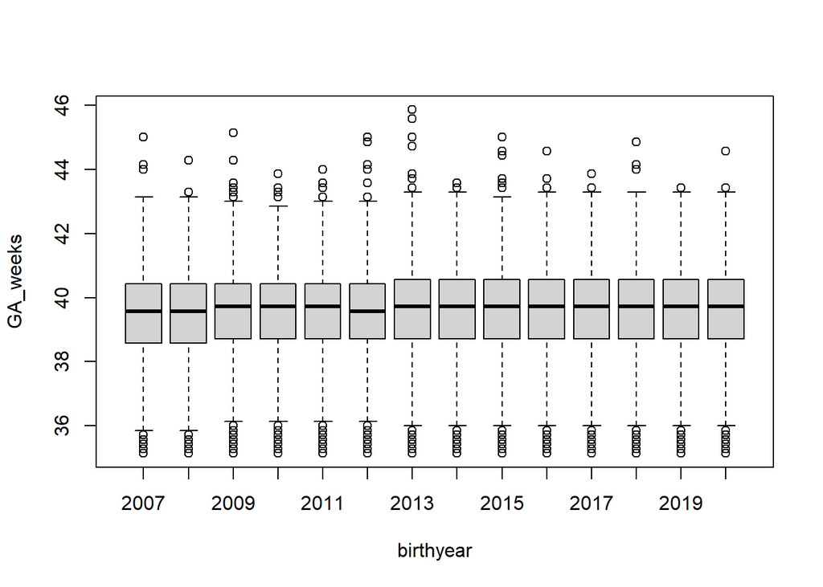

```r
  #subset with GA over 35 weeks
  boxplot(GA_weeks ~birthyear, data=bevn_eco_in7, subset = GA_weeks>35)
```

## Birthweight through the years

```r
BW_median2 <- aggregate(BW ~ birthyear, data = bevn_eco_in7, median)
BW_median2
```

```
##    birthyear   BW
## 1       2007 3350
## 2       2008 3350
## 3       2009 3340
## 4       2010 3350
## 5       2011 3350
## 6       2012 3350
## 7       2013 3340
## 8       2014 3340
## 9       2015 3345
## 10      2016 3340
## 11      2017 3350
## 12      2018 3340
## 13      2019 3350
## 14      2020 3360
```

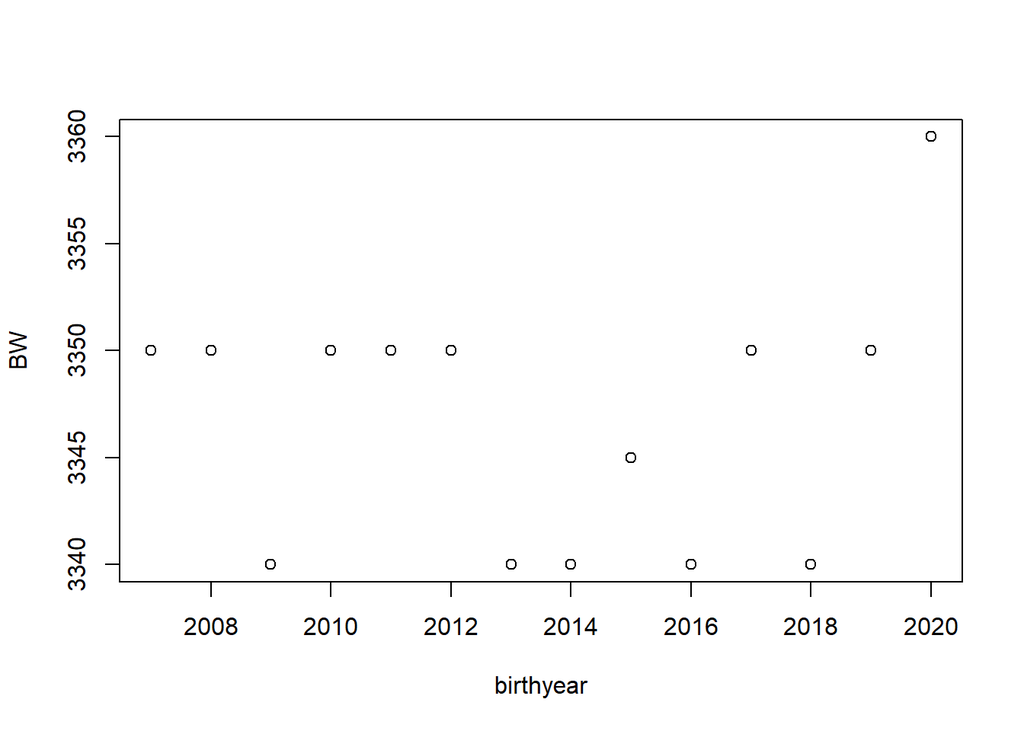

```r
plot(BW_median2)
```

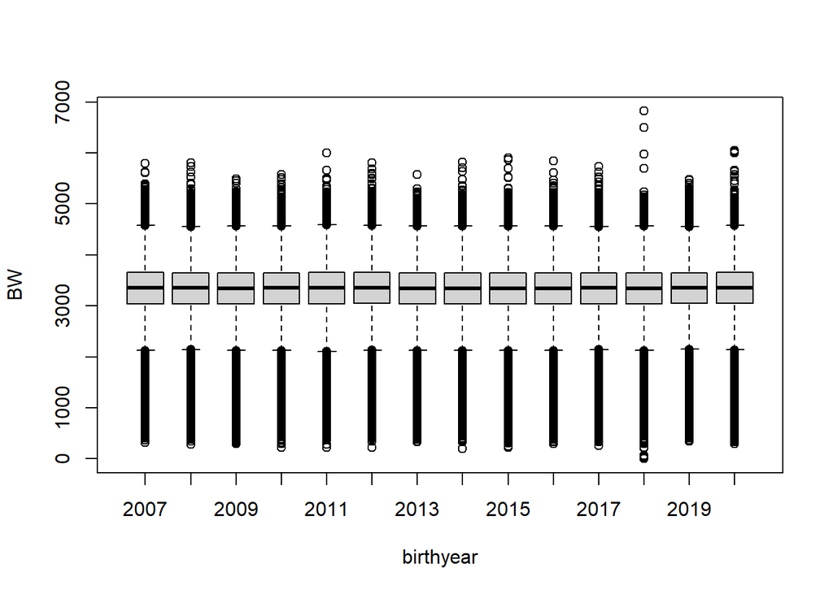

```r
boxplot(BW~birthyear, data=bevn_eco_in7, subset= BW<8000)
```

## Birth length through the years

```r
BL_median <- aggregate(BL ~ birthyear, data = bevn_eco_in7, median)
BL_median
```

```
##    birthyear BL
## 1       2007 50
## 2       2008 50
## 3       2009 50
## 4       2010 50
## 5       2011 50
## 6       2012 50
## 7       2013 50
## 8       2014 50
## 9       2015 50
## 10      2016 50
## 11      2017 50
## 12      2018 50
## 13      2019 50
## 14      2020 50
```

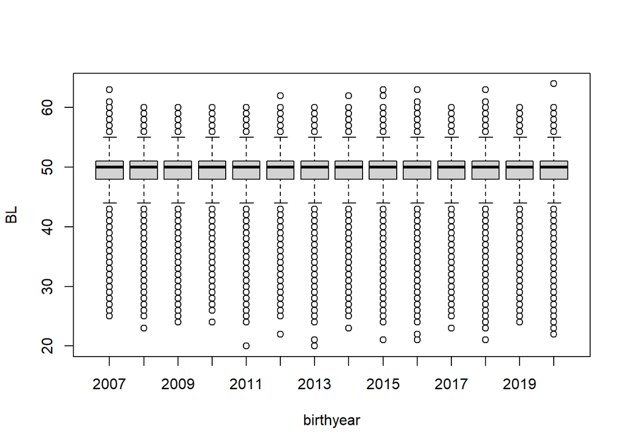

```r
boxplot(BL~birthyear, data=bevn_eco_in7)
```

## Sex % through the years

```r
table(bevn_eco_in7$sex, bevn_eco_in7$birthyear)
```

```
##
##      2007  2008  2009  2010  2011  2012  2013  2014  2015  2016  2017  2018  2019  2020
##   1 33104 35479 38689 39543 39945 40731 40821 42106 42890 43108 43067 43152 42485 42720
##   2 31458 33327 36283 37576 37652 38009 38489 39659 40157 41160 40676 40993 40454 40080
```

```r
round(prop.table(table(bevn_eco_in7$sex, bevn_eco_in7$birthyear), margin=2)*100,2)
```

```
##
##      2007  2008  2009  2010  2011  2012  2013  2014  2015  2016  2017  2018  2019  2020
##   1 51.27 51.56 51.60 51.28 51.48 51.73 51.47 51.50 51.65 51.16 51.43 51.28 51.22 51.59
##   2 48.73 48.44 48.40 48.72 48.52 48.27 48.53 48.50 48.35 48.84 48.57 48.72 48.78 48.41
```